# Study I: EIV-GP results and mixing assessment

# Scope and completion

This report reads the saved **EIV-GP lane** of Study I. It includes the oracle and supplementary controls present in this run. External UC-GP, LVGP and EzGP comparisons belong to the competitor lane and are not claimed here.

Selected run: `/Volumes/data/eivGP/study1-eivGP/core/study1-publication-v2-9d3ac08614b5`.

Saved execution status (historical gate warnings are not execution failures).

| cell id | status | message | elapsed seconds |
| --- | --- | --- | --- |
| eta0_balanced | success | NA | 45430.02 |
| eta1_balanced | success | NA | 52130.49 |

Saved study design.

| cell | replications | training | test | classes | calibration |
| --- | --- | --- | --- | --- | --- |
| eta0_balanced | 50 | 100 | 100 | 6 | 0, 20, 50 |
| eta1_balanced | 50 | 100 | 100 | 6 | 0, 20, 50 |

Scores below retain every completed replication. **No results are excluded because of a diagnostic flag.** Values are replication means; brackets contain the between-replication Monte Carlo standard error and the finite replication count. Those MCSEs differ from within-fit MCMC error.

# Prediction of a new response

Lower RMSE, CRPS, NLPD and interval score are better. Coverage95 and Width95 must be read together; nominal coverage is 0.95. Oracle rows have no calibration size because they are a reference shared across calibration settings.

Predictive performance.

| cell id | n calib | method | RMSE | CRPS | NLPD | Coverage95 | Width95 | IntervalScore95 |
| --- | --- | --- | --- | --- | --- | --- | --- | --- |
| eta0_balanced | 0 | EIV-GP | 0.169 [0.002; 50] | 0.091 [0.001; 50] | -0.413 [0.010; 50] | 0.981 [0.003; 50] | 1.015 [0.006; 50] | 1.055 [0.008; 50] |
| eta0_balanced | 20 | EIV-GP | 0.180 [0.003; 50] | 0.098 [0.001; 50] | -0.328 [0.011; 50] | 0.989 [0.002; 50] | 1.064 [0.009; 50] | 1.089 [0.008; 50] |
| eta0_balanced | 50 | EIV-GP | 0.183 [0.003; 50] | 0.106 [0.001; 50] | -0.187 [0.011; 50] | 0.997 [0.001; 50] | 1.184 [0.013; 50] | 1.189 [0.013; 50] |
| eta0_balanced | Not applicable | Oracle | 0.101 [0.001; 50] | 0.057 [0.001; 50] | -0.873 [0.011; 50] | 0.943 [0.003; 50] | 0.389 [0.000; 50] | 0.479 [0.006; 50] |
| eta1_balanced | 0 | EIV-GP | 0.514 [0.007; 50] | 0.270 [0.004; 50] | 0.508 [0.013; 50] | 0.955 [0.005; 50] | 1.679 [0.014; 50] | 2.010 [0.049; 50] |
| eta1_balanced | 20 | EIV-GP | 0.502 [0.007; 50] | 0.261 [0.004; 50] | 0.445 [0.013; 50] | 0.947 [0.004; 50] | 1.586 [0.012; 50] | 1.875 [0.041; 50] |
| eta1_balanced | 50 | EIV-GP | 0.493 [0.006; 50] | 0.255 [0.003; 50] | 0.396 [0.011; 50] | 0.945 [0.004; 50] | 1.531 [0.012; 50] | 1.764 [0.032; 50] |
| eta1_balanced | Not applicable | Oracle | 0.483 [0.005; 50] | 0.247 [0.003; 50] | 0.297 [0.009; 50] | 0.941 [0.003; 50] | 1.432 [0.008; 50] | 1.560 [0.010; 50] |

# Observed-input mean m(x,c)

These summaries evaluate the mean conditional on the observed covariates and ordinal class, integrating the unobserved input.

Recovery of m(x,c).

| cell id | n calib | method | RMSE | Bias | Coverage95 | Width95 |
| --- | --- | --- | --- | --- | --- | --- |
| eta0_balanced | 0 | EIV-GP | 0.136 [0.003; 50] | 0.016 [0.003; 50] | 0.920 [0.009; 50] | 0.441 [0.003; 50] |
| eta0_balanced | 20 | EIV-GP | 0.149 [0.004; 50] | 0.012 [0.003; 50] | 0.860 [0.011; 50] | 0.431 [0.004; 50] |
| eta0_balanced | 50 | EIV-GP | 0.151 [0.003; 50] | 0.012 [0.003; 50] | 0.875 [0.009; 50] | 0.447 [0.006; 50] |
| eta1_balanced | 0 | EIV-GP | 0.169 [0.007; 50] | 0.011 [0.007; 50] | 0.952 [0.008; 50] | 0.637 [0.007; 50] |
| eta1_balanced | 20 | EIV-GP | 0.126 [0.006; 50] | 0.003 [0.005; 50] | 0.964 [0.007; 50] | 0.493 [0.007; 50] |
| eta1_balanced | 50 | EIV-GP | 0.094 [0.004; 50] | 0.002 [0.004; 50] | 0.966 [0.006; 50] | 0.368 [0.006; 50] |

# Latent response surface f(x,u)

Surface recovery is assessed for eta=1 with calibration. It is not scored on an unanchored latent-input scale.

Recovery of f(x,u).

| cell id | n calib | method | ISE | Bias | Coverage95 | Width95 |
| --- | --- | --- | --- | --- | --- | --- |
| eta1_balanced | 20 | EIV-GP | 0.098 [0.008; 50] | -0.079 [0.010; 50] | 0.957 [0.005; 50] | 0.961 [0.016; 50] |
| eta1_balanced | 50 | EIV-GP | 0.056 [0.004; 50] | -0.049 [0.007; 50] | 0.961 [0.004; 50] | 0.689 [0.013; 50] |

# Training latent-input imputation

Without calibration, the physical location and scale of U are unanchored; those rows are explicitly not scored.

Imputation of unobserved training inputs.

| cell id | n calib | method | RMSE | Bias | Coverage95 | Width95 |
| --- | --- | --- | --- | --- | --- | --- |
| eta0_balanced | 0 | EIV-GP | Not scored | Not scored | Not scored | Not scored |
| eta0_balanced | 0 | Response-free threshold model | Not scored | Not scored | Not scored | Not scored |
| eta0_balanced | 20 | EIV-GP | 0.306 [0.007; 50] | -0.009 [0.008; 50] | 0.783 [0.007; 50] | 0.727 [0.007; 50] |
| eta0_balanced | 20 | Response-free threshold model | 0.288 [0.007; 50] | -0.006 [0.007; 50] | 0.956 [0.003; 50] | 0.931 [0.008; 50] |
| eta0_balanced | 50 | EIV-GP | 0.289 [0.010; 50] | -0.001 [0.006; 50] | 0.832 [0.010; 50] | 0.738 [0.008; 50] |
| eta0_balanced | 50 | Response-free threshold model | 0.279 [0.009; 50] | -0.003 [0.006; 50] | 0.954 [0.004; 50] | 0.884 [0.009; 50] |
| eta1_balanced | 0 | EIV-GP | Not scored | Not scored | Not scored | Not scored |
| eta1_balanced | 0 | Response-free threshold model | Not scored | Not scored | Not scored | Not scored |
| eta1_balanced | 20 | EIV-GP | 0.175 [0.010; 50] | -0.004 [0.005; 50] | 0.974 [0.003; 50] | 0.534 [0.009; 50] |
| eta1_balanced | 20 | Response-free threshold model | 0.288 [0.007; 50] | -0.006 [0.007; 50] | 0.956 [0.003; 50] | 0.931 [0.008; 50] |
| eta1_balanced | 50 | EIV-GP | 0.162 [0.013; 50] | -0.007 [0.004; 50] | 0.969 [0.004; 50] | 0.424 [0.006; 50] |
| eta1_balanced | 50 | Response-free threshold model | 0.279 [0.009; 50] | -0.003 [0.006; 50] | 0.954 [0.004; 50] | 0.884 [0.009; 50] |

# Supplementary controls

These controls diagnose the role of input uncertainty and available calibration; they are not substitutes for the separately fitted published competitors.

Predictive controls.

| cell id | n calib | method | RMSE | CRPS | Coverage95 | Width95 |
| --- | --- | --- | --- | --- | --- | --- |
| eta0_balanced | 0 | PI-GP | 0.117 [0.001; 50] | 0.066 [0.001; 50] | 0.943 [0.005; 50] | 0.446 [0.005; 50] |
| eta0_balanced | 20 | CC-GP | 0.405 [0.015; 50] | 0.226 [0.010; 50] | 0.923 [0.014; 50] | 1.589 [0.036; 50] |
| eta0_balanced | 20 | PI-GP | 0.128 [0.002; 50] | 0.071 [0.001; 50] | 0.952 [0.005; 50] | 0.497 [0.007; 50] |
| eta0_balanced | 50 | CC-GP | 0.243 [0.006; 50] | 0.138 [0.003; 50] | 0.989 [0.003; 50] | 1.406 [0.024; 50] |
| eta0_balanced | 50 | PI-GP | 0.142 [0.003; 50] | 0.080 [0.001; 50] | 0.967 [0.004; 50] | 0.638 [0.017; 50] |
| eta1_balanced | 0 | PI-GP | 0.537 [0.008; 50] | 0.299 [0.004; 50] | 0.926 [0.005; 50] | 1.983 [0.023; 50] |
| eta1_balanced | 20 | CC-GP | 0.571 [0.008; 50] | 0.312 [0.005; 50] | 0.883 [0.010; 50] | 1.740 [0.022; 50] |
| eta1_balanced | 20 | PI-GP | 0.534 [0.008; 50] | 0.295 [0.005; 50] | 0.903 [0.006; 50] | 1.782 [0.026; 50] |
| eta1_balanced | 50 | CC-GP | 0.499 [0.006; 50] | 0.260 [0.003; 50] | 0.936 [0.004; 50] | 1.575 [0.015; 50] |
| eta1_balanced | 50 | PI-GP | 0.528 [0.008; 50] | 0.294 [0.005; 50] | 0.849 [0.008; 50] | 1.416 [0.029; 50] |

Surface-recovery controls.

| cell id | n calib | method | ISE | Coverage95 | Width95 |
| --- | --- | --- | --- | --- | --- |
| eta1_balanced | 20 | CC-GP | 0.274 [0.025; 50] | 0.871 [0.016; 50] | 1.459 [0.034; 50] |
| eta1_balanced | 20 | PI-GP | 0.222 [0.008; 50] | 0.883 [0.009; 50] | 1.269 [0.018; 50] |
| eta1_balanced | 50 | CC-GP | 0.074 [0.007; 50] | 0.948 [0.006; 50] | 0.830 [0.020; 50] |
| eta1_balanced | 50 | PI-GP | 0.122 [0.007; 50] | 0.922 [0.009; 50] | 1.055 [0.019; 50] |
| eta1_balanced | Not applicable | Full-U GP | 0.037 [0.003; 50] | 0.953 [0.005; 50] | 0.517 [0.013; 50] |

# Scientific-target ESS and mixing

The requested criterion is **bulk ESS > 100 and tail ESS > 100**, across the retained chains. R-hat and mean MCSE relative to posterior SD are supporting diagnostics, not additional pass/fail gates in this report. Missing ESS is listed as unavailable. Raw-coordinate and historical overall gate counts do not decide acceptability.

The fits listed below were continued from their saved terminal states until every monitored scientific target exceeded the ESS requirement. All original post-warmup draws were retained; their scores were recomputed from the combined chains. Other fits were reused.

Saved-state continuations (iterations per chain).

| cell id | rep | n calib | n iter | burn | saved per chain |
| --- | --- | --- | --- | --- | --- |
| eta1_balanced | 15 | 20 | 40000 | 5000 | 35000 |
| eta1_balanced | 21 | 0 | 60000 | 5000 | 55000 |

Diagnostics use the complete retained chain windows recorded in the saved run. Scientific targets are monitored at five test locations per fit; this is not an exhaustive check over the whole prediction domain. Conditional-mean and second-moment diagnostics address different estimands. Target integrations use the saved finite integration design; their ESS does not measure integration approximation error.

Scientific-target diagnostics across all replications. Full summaries and counts are retained in target_ess_summary.csv.

| eta | \|O\| | Target | Median bulk | Min bulk | Min tail | Max R-hat | Max MCSE/SD | ESS <= 100 |
| --- | --- | --- | --- | --- | --- | --- | --- | --- |
| 1 | 20 | f mean | 1334 | 144 | 231 | 1.027 | 0.090 | 0 |
| 1 | 50 | f mean | 2524 | 725 | 872 | 1.009 | 0.037 | 0 |
| 1 | 20 | f variance | 615 | 101 | 356 | 1.037 | 0.083 | 0 |
| 1 | 50 | f variance | 1709 | 728 | 912 | 1.009 | 0.037 | 0 |
| 0 | 0 | m mean | 2138 | 534 | 883 | 1.013 | 0.046 | 0 |
| 1 | 0 | m mean | 1655 | 218 | 177 | 1.019 | 0.073 | 0 |
| 0 | 20 | m mean | 5072 | 952 | 2100 | 1.005 | 0.033 | 0 |
| 1 | 20 | m mean | 1519 | 173 | 145 | 1.022 | 0.083 | 0 |
| 0 | 50 | m mean | 14278 | 4187 | 8846 | 1.001 | 0.016 | 0 |
| 1 | 50 | m mean | 2726 | 607 | 903 | 1.008 | 0.041 | 0 |
| 0 | 0 | m variance | 1156 | 287 | 185 | 1.021 | 0.055 | 0 |
| 1 | 0 | m variance | 626 | 174 | 321 | 1.024 | 0.072 | 0 |
| 0 | 20 | m variance | 4478 | 867 | 1485 | 1.008 | 0.032 | 0 |
| 1 | 20 | m variance | 681 | 103 | 287 | 1.038 | 0.082 | 0 |
| 0 | 50 | m variance | 16380 | 5124 | 8907 | 1.001 | 0.014 | 0 |
| 1 | 50 | m variance | 1877 | 710 | 1212 | 1.008 | 0.036 | 0 |
| 0 | 0 | Predictive second moment | 2404 | 297 | 481 | 1.010 | 0.056 | 0 |
| 1 | 0 | Predictive second moment | 1819 | 271 | 198 | 1.016 | 0.062 | 0 |
| 0 | 20 | Predictive second moment | 5264 | 873 | 2145 | 1.006 | 0.033 | 0 |
| 1 | 20 | Predictive second moment | 1589 | 149 | 108 | 1.030 | 0.081 | 0 |
| 0 | 50 | Predictive second moment | 14798 | 4763 | 7455 | 1.001 | 0.015 | 0 |
| 1 | 50 | Predictive second moment | 2757 | 562 | 904 | 1.009 | 0.043 | 0 |
| 0 | 20 | Prospective U mean | 2027 | 579 | 1103 | 1.010 | 0.042 | 0 |
| 1 | 20 | Prospective U mean | 1053 | 246 | 582 | 1.021 | 0.065 | 0 |
| 0 | 50 | Prospective U mean | 11523 | 1882 | 4018 | 1.002 | 0.023 | 0 |
| 1 | 50 | Prospective U mean | 3056 | 437 | 484 | 1.012 | 0.048 | 0 |
| 0 | 20 | Prospective U second moment | 2127 | 542 | 1103 | 1.012 | 0.043 | 0 |
| 1 | 20 | Prospective U second moment | 1081 | 237 | 570 | 1.021 | 0.066 | 0 |
| 0 | 50 | Prospective U second moment | 11835 | 1802 | 3771 | 1.002 | 0.024 | 0 |
| 1 | 50 | Prospective U second moment | 3074 | 510 | 484 | 1.012 | 0.044 | 0 |

## Targets requiring closer inspection

All saved monitored targets have finite bulk and tail ESS above the requested threshold. Trace inspection remains necessary.

## Inspection of the saved traces

All 7,500 monitored scientific-target quantities across the 300 Study I fits now have finite bulk and tail ESS strictly greater than 100. The two extended fits preserve every original post-warmup state and resume the saved terminal states and RNG streams. The other 298 fits were reused.

Replication 15, eta=1 with 20 calibration inputs, has 40,000 total iterations per chain (35,000 retained). Its weakest predictive second moment has bulk ESS 149.1, tail ESS 108.1 and R-hat 1.030; mean MCSE is 8.1% of posterior SD. Its weakest observable mean has bulk ESS 299.0, tail ESS 145.2 and R-hat 1.020. The traces retain an early chain-3 excursion and show shorter excursions late in the extension. The chains return to overlapping regions, but the uncertainty target remains only modestly above the requested precision threshold.

These two fits meet the requested working-precision criterion for the monitored scientific targets. Their mixing is usable with qualification, rather than uniformly rapid: slow excursions and residual Monte Carlo error remain. Some unchanged fits are also close to the threshold (the overall minimum bulk ESS is 101.3). Small numerical differences should therefore not be overinterpreted. These checks cover a five-location panel with a fixed finite latent-integration design; they do not certify every latent coordinate, every prediction location, or integration approximation error.

# A few chain trace plots

Three figures show typical observable-mean targets, the weakest uncertainty targets, and the continued scientific targets when extensions are present (otherwise, the weakest mean targets). The continued-target figure follows the weakest observable mean and predictive second moment in each extended fit; its dashed line marks the original 20,000-iteration endpoint. Typical replications are chosen near the median of the per-fit minimum m-mean bulk ESS; among historical archives only available retained fits can be traced. Weak cases are selected by the smallest bulk/tail ESS. The selection table and unavailable traces are retained.

Traces use evenly spaced states across the entire post-warmup window, with four chains overlaid. ESS labels use the full-window diagnostic tables, never the displayed subset. No new MCMC is run.

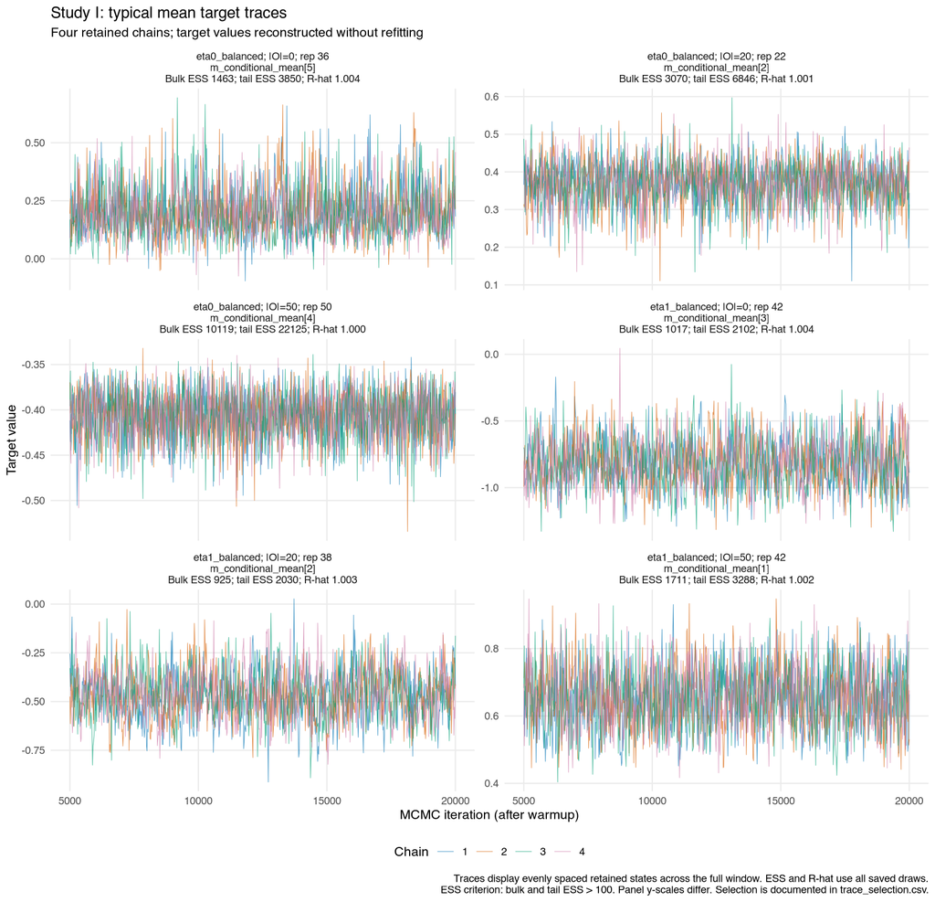

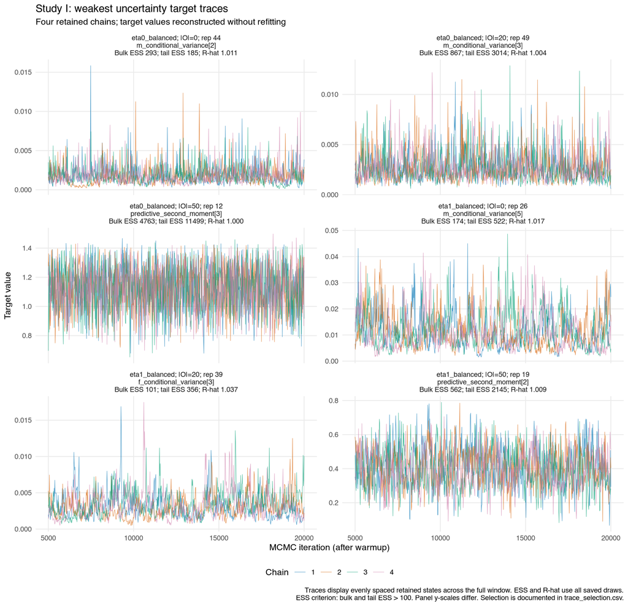

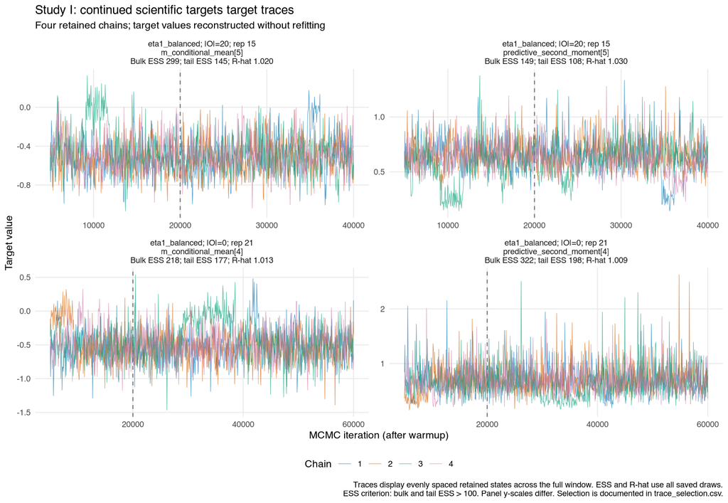

# Output completeness and provenance

Saved output-completeness checks.

| cell id | gate | expected | attempted | success | pass |
| --- | --- | --- | --- | --- | --- |
| eta0_balanced | prediction_output_completeness | 200 | 200 | 200 | TRUE |
| eta0_balanced | observable_mean_output_completeness | 150 | 150 | 150 | TRUE |
| eta0_balanced | ablation_prediction_output_completeness | 250 | 250 | 250 | TRUE |
| eta0_balanced | training_latent_u_output_completeness | 300 | 300 | 300 | TRUE |
| eta1_balanced | prediction_output_completeness | 200 | 200 | 200 | TRUE |
| eta1_balanced | observable_mean_output_completeness | 150 | 150 | 150 | TRUE |
| eta1_balanced | ablation_prediction_output_completeness | 250 | 250 | 250 | TRUE |
| eta1_balanced | latent_surface_eiv_output_completeness | 100 | 100 | 100 | TRUE |
| eta1_balanced | latent_surface_benchmark_output_completeness | 250 | 250 | 250 | TRUE |
| eta1_balanced | training_latent_u_output_completeness | 300 | 300 | 300 | TRUE |

Supplementary method execution statuses.

| Var1 | Var2 | Var3 | Freq |
| --- | --- | --- | --- |
| eta0_balanced | CC-GP | not_applicable | 50 |
| eta1_balanced | CC-GP | not_applicable | 50 |
| eta0_balanced | Full-U GP | not_applicable | 0 |
| eta1_balanced | Full-U GP | not_applicable | 0 |
| eta0_balanced | PI-GP | not_applicable | 0 |
| eta1_balanced | PI-GP | not_applicable | 0 |
| eta0_balanced | Response-free threshold model | not_applicable | 0 |
| eta1_balanced | Response-free threshold model | not_applicable | 0 |
| eta0_balanced | CC-GP | success | 100 |
| eta1_balanced | CC-GP | success | 100 |
| eta0_balanced | Full-U GP | success | 0 |
| eta1_balanced | Full-U GP | success | 50 |
| eta0_balanced | PI-GP | success | 150 |
| eta1_balanced | PI-GP | success | 150 |
| eta0_balanced | Response-free threshold model | success | 150 |
| eta1_balanced | Response-free threshold model | success | 150 |

Report data and CSV summaries: `/Users/sheng/Documents/ChatGPT/mixed-inputGP/study1-recovery-20261024/report`. The source manifest records input file checksums. Saved results include verified continuations where requested; rendering this report does not alter fits or scores.

To regenerate without fitting, run `study1-eivGP.R --action=report --run-dir=... --data-root=... --report-output=...`. For a new simulation use `--action=run`; the same script prepares and renders this HTML report. Rendering this notebook never fits or continues chains.

```
## [1] '0.4.0.9014'
```